# Assignment2.rmd

#Calculate min,max,mean,median,sd,iqr and store.

This table show the information about age of survived between the female and male. Use the Median to calculate the group of age that can survived.The median form female is equal to 28 and it equal to male. The first Quantile is 19 that slightly more then male that 18. Also the value of third Quantile from female still more than meal equal to 2. Although, some number of survived have been removed before use to calculate because of value of age is NA.

Number of Calculate Age of survive

```r
kable(sumdata)
```

| Min | Max | Mean | Median | SD | IQR |
| --- | --- | --- | --- | --- | --- |
| 0.42 | 80 | 28.34369 | 28 | 14.95095 | 17 |

#Show the table of sumdata in the RMarkdown

```r
Quantile = quantile(table2$Age)
kable(Quantile, caption = "Quantile of their Age")
```

Quantile of their Age

|  | x |
| --- | --- |
| 0% | 0.42 |
| 25% | 19.00 |
| 50% | 28.00 |
| 75% | 36.00 |
| 100% | 80.00 |

#calcolate and show each of % of Quantile like 0 25 50 75 and 100

This is the plot graph for Age and sex of the titanic data.

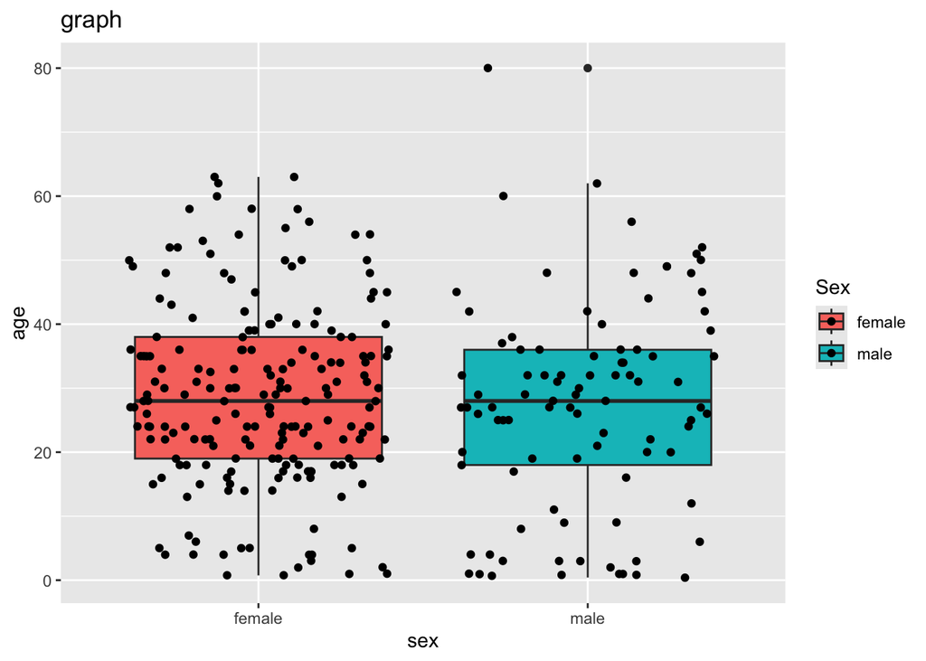

```r
qplot(factor(table2$Sex),table2$Age, data = table2, geom = c("boxplot","jitter"), fill =Sex, main= "graph", xlab = "sex" ,ylab = "age")
```

#plot the number of Survived and age devided by sex.

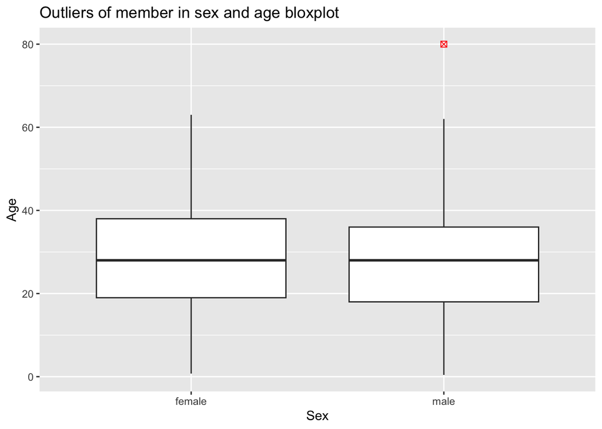

```r
ggplot (table2, aes(x = as.factor(Sex), y = Age)) +
  geom_boxplot(outlier.colour = "red", outlier.shape = 7, outlier.size = 2) +
  labs(x = "Sex", y = "Age", title = "Outliers of member in sex and age bloxplot")
```

#plot the out liner with the red colour to show the member that out of the range.